# IS607 - Tidying and Transforming Data

March 7, 2015

## Week 7 Assignment: Tidying and Transforming Data

In a recent mythical poll in Scotland, voters were asked if they preferred Cullen skink over Partan bree. Here are the results of the poll, with results broken down by city and by age group.

[figure not shown]

## The data raises the following questions:

- How many people in each city participated in the poll?
- How many people in total prefer Cullen skink by city?
- How many people in total prefer Partan bree by city?
- Can we visualize the data?
- What does this all mean?

## Getting the data

```r
data.messy <- data.frame(response=as.factor(c("Yes","No"))
                         ,edinburgh.16_24=c(80100,35900)
                         ,edinburgh.25_plus=c(143000,214800)
                         ,glasgow.16_24=c(99400,43000)
                         ,glasgow.25_plus=c(150400,207400)
                         )
(data.messy)
```

```
##   response edinburgh.16_24 edinburgh.25_plus glasgow.16_24 glasgow.25_plus
## 1      Yes           80100            143000         99400          150400
## 2       No           35900            214800         43000          207400
```

## Tidying the Data

```r
data.tidy <- data.messy %>%
  gather(variable, value, -response) %>%
  separate(variable,into=c("city","age.group"),extra="merge")%>%
  rename(preference=response)%>%
  arrange(city,age.group,preference)

levels(data.tidy$preference) <- list("Cullen skink"="Yes"
                                     ,"Partan bree"="No")
head(data.tidy)
```

```
##     preference      city age.group  value
## 1  Partan bree edinburgh     16_24  35900
## 2 Cullen skink edinburgh     16_24  80100
## 3  Partan bree edinburgh   25_plus 214800
## 4 Cullen skink edinburgh   25_plus 143000
## 5  Partan bree   glasgow     16_24  43000
## 6 Cullen skink   glasgow     16_24  99400
```

## How many people in each city participated in the poll?

```r
data.tidy %>%
  group_by(city) %>%
  summarise(
    total_participants = sum(value)
    )
```

```
## Source: local data frame [2 x 2]
##
##        city total_participants
## 1 edinburgh             473800
## 2   glasgow             500200
```

## How many people in total prefer Cullen skink by city?

```r
data.tidy %>%
  filter(preference=="Cullen skink") %>%
  group_by(city) %>%
  summarise(
    prefer_cullen_skink_total = sum(value)
    )
```

```
## Source: local data frame [2 x 2]
##
##        city prefer_cullen_skink_total
## 1 edinburgh                    223100
## 2   glasgow                    249800
```

**Glasgow is of Cullen Skink capital!!**

## How many people in total prefer Partan bree by city?

```r
data.tidy %>%
  filter(preference=="Partan bree") %>%
  group_by(city) %>%
  summarise(
    prefer_partan_bree_total = sum(value)
    )
```

```
## Source: local data frame [2 x 2]
##
##        city prefer_partan_bree_total
## 1 edinburgh                   250700
## 2   glasgow                   250400
```

**It seems that Partan bree rules in both Glasgow and and Edinburgh**

## Can we visualize the data?

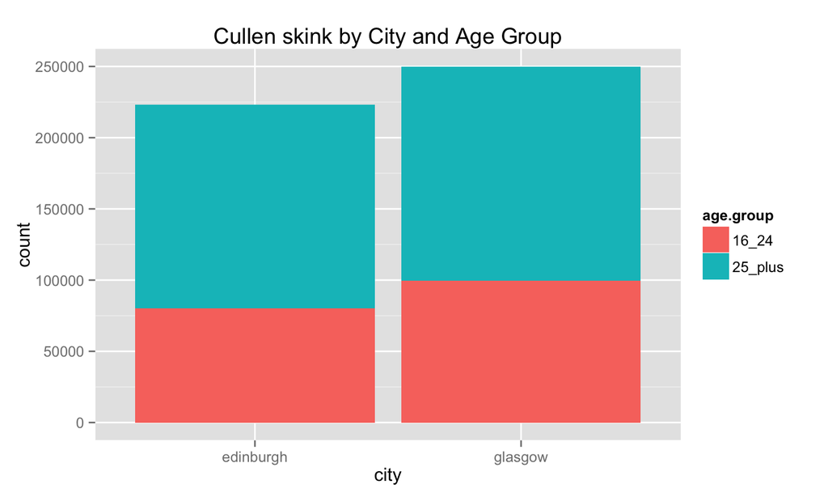

## Can we visualize the data?

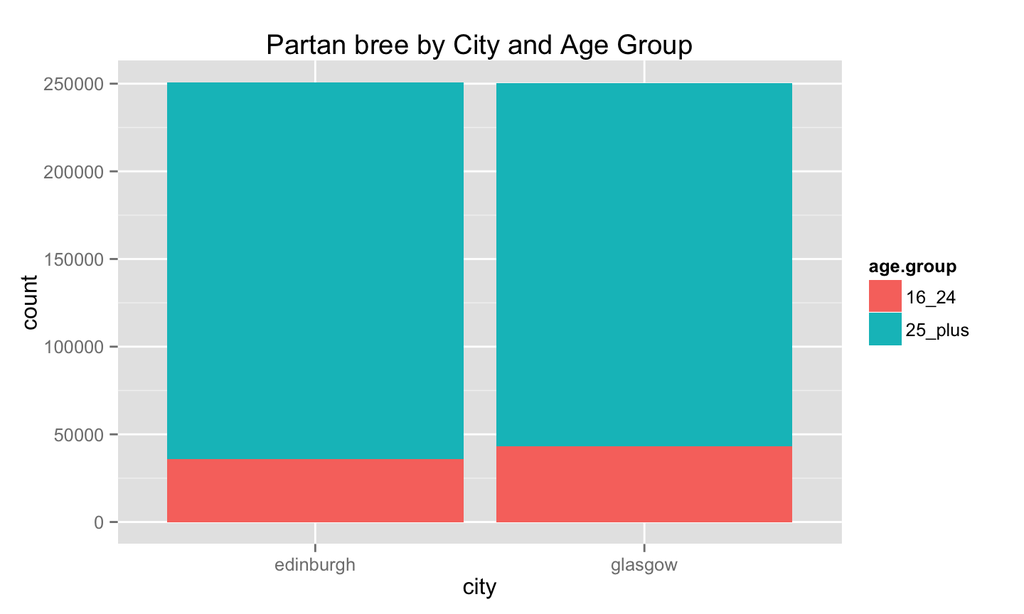

## What does this all mean?

**For Partan Bree:**

- People in Edinburgh and Glasgow equally like their Partan Bree
- Those under 25 do not seem to like it as much as those over 25

**For Cullen Skink:**

- People in Glasgow like it more
- In overall, it is not as popular as Partan Bree
- Even though it is preferred mostly by those over 25, those under 25 seem to like it as well.